# ggplot2

## Another perspective with dotplots (Vertical bins)

> What if we want to compare the distribution of Infection (No vs Yes) side by side ? We will need to map the infection variable to the x axis and move the age variable to the y axis. We’ll also keep the infection variable with the `fill` argument that way it’ll retain the color

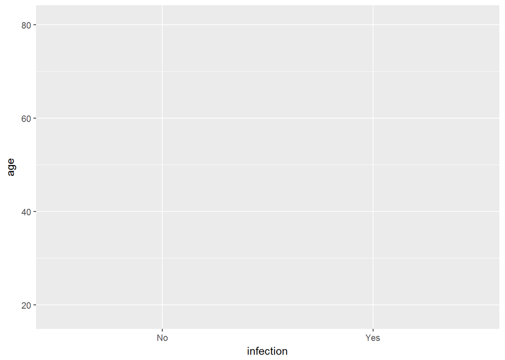

```r
ggplot(df, aes(y = age, x = infection, fill = infection))
```

> Now we have the basis of the plot, we can add the dotplot geom once again, except we’ll bin the histodots on the y axis instead of x and keep the stack them aligned to the center.

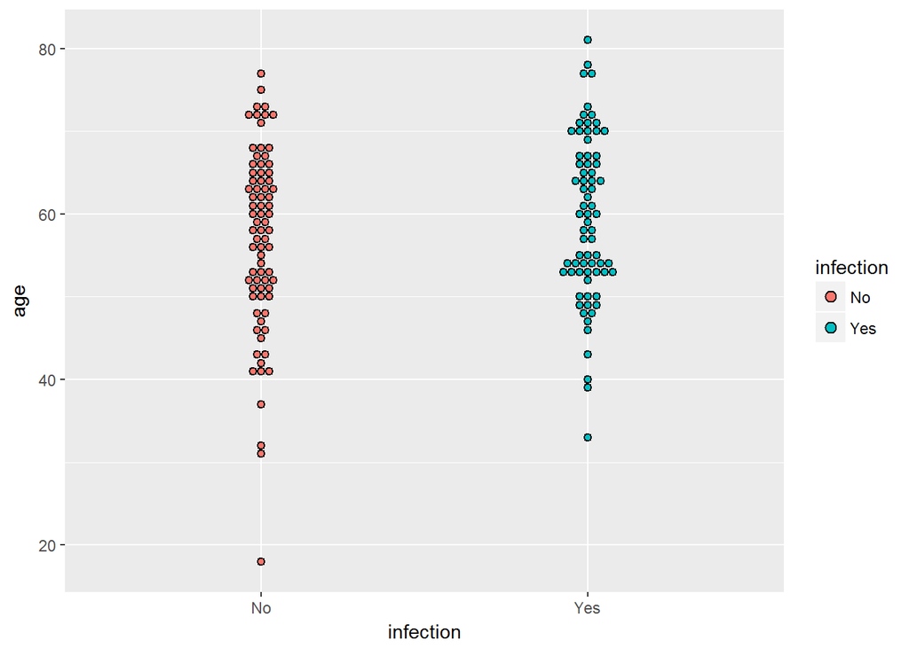

```r
ggplot(df, aes(y = age, x = infection, fill = infection)) +
  geom_dotplot(binaxis = "y", stackdir = "center",
               binwidth = 1, method = "histodot")
```

> Now let’s add some descriptive indicators on the plot via the `stat_summary()` function. Let’s add an indicator of the medians for both the non infection group and the infection group. `stat_summary()` allows us to map a function to the y axis. We will use the `median` function to accomplish this, and use the geom crossbar to visualize the measure.

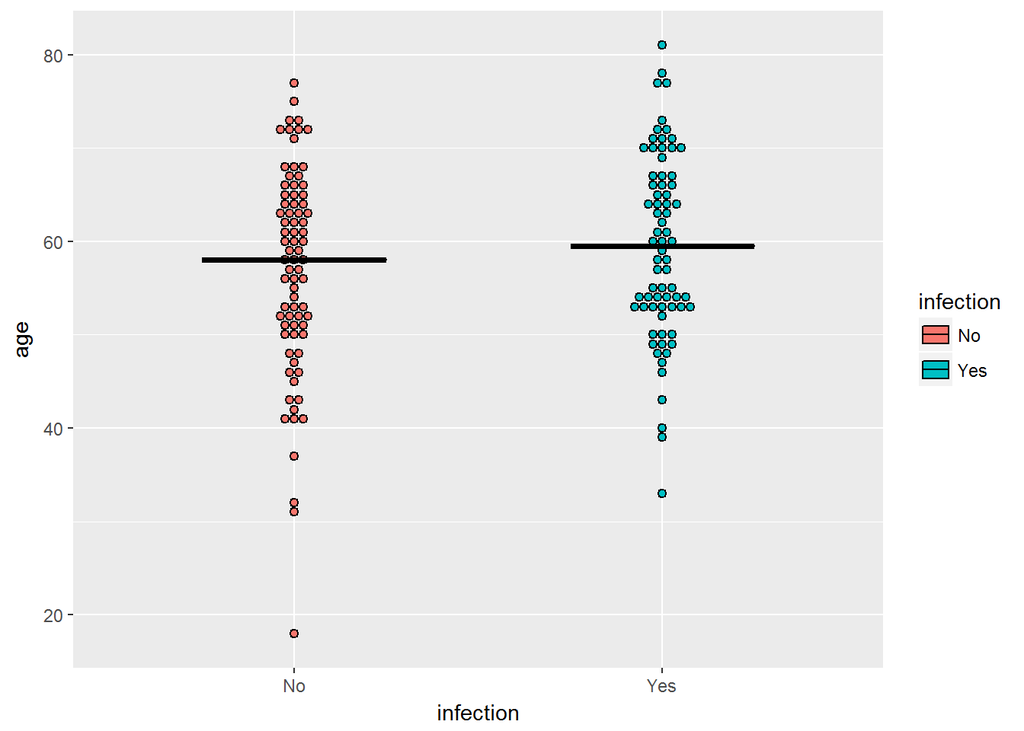

```r
ggplot(df, aes(y = age, x = infection, fill = infection)) +
  geom_dotplot(binaxis = "y", stackdir = "center",
               binwidth = 1, method = "histodot") +
  stat_summary(fun.y = median, fun.ymin = median, fun.ymax = median, geom = "crossbar", width = 0.5)
```

> Let’s finish cleaning up the plot with some of the other functions we have learned

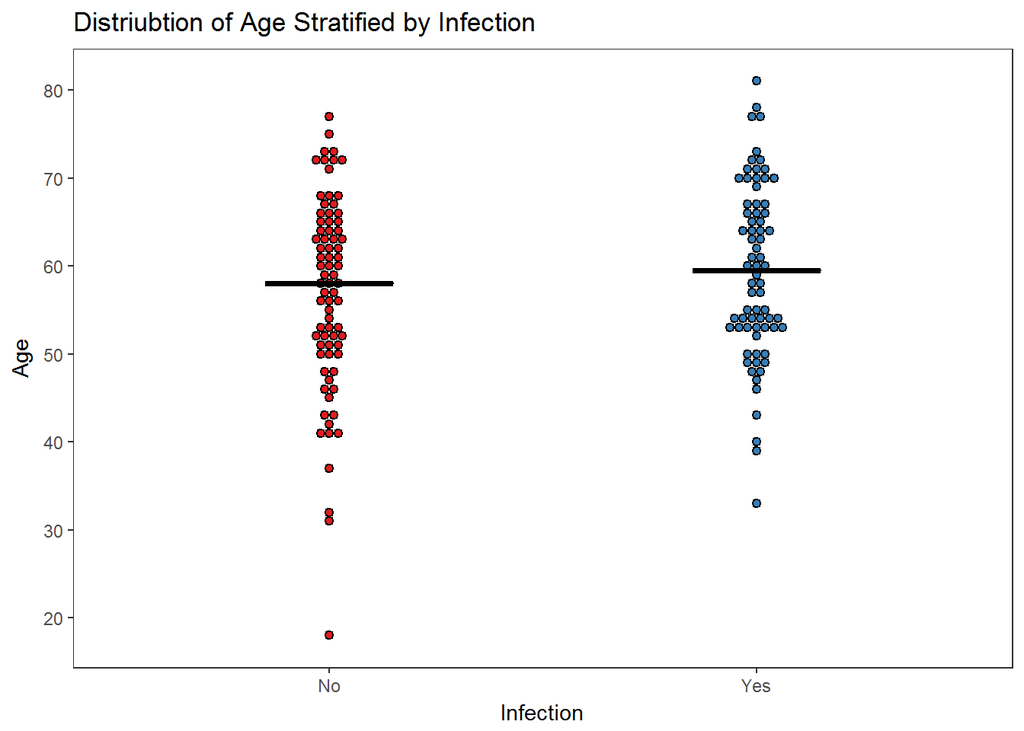

```r
# manually calculate the median age by infection group

ggplot(df, aes(y = age, x = infection, fill = infection)) +
  geom_dotplot(binaxis = "y", stackdir = "center",
               binwidth = 1, method = "histodot") +
  stat_summary(fun.y = median, fun.ymin = median, fun.ymax = median, geom = "crossbar", width = 0.3) +
  theme_bw() +
  theme(legend.position = "none",
        panel.grid = element_blank()) +
  scale_fill_brewer("infection", palette = "Set1") +
  labs(y = "Age", x = "Infection", title = 'Distriubtion of Age Stratified by Infection') +
  scale_y_continuous(breaks = seq(0,100, 10))
```

# Saving the plot we just made

> Now that we are happy with the plot we just made, we should save it so we can share it with our collaborators. There are we can do this by invoking the `ggsave()` function. By default `ggsave()` will save the last plot that was rendered, however we can also specify the plot we would like to save as well.

> The command for `ggsave()` is `ggsave(filename = NULL, plot = last_plot(), ...)`. Please see the documentation for further details using `?ggsave`, for other possible arguments to configure.

```r
ggsave('my_first_plot.png', height = 6, width = 8)
```

> This function will save the previous plot, in your project directory as my_first_plot.png, with a height of 6 inches, and a width of 8 inches.